# Exercise

```r
set.seed(29)
```

```r
library(LearnBayes)
```

## 2-1

### 事前分布の設定

```r
p = seq(0, 1, by=0.125)
prior = c(0.001, 0.001, 0.950, 0.008, 0.008, 0.008, 0.008, 0.008, 0.008)
sum(prior)
```

```
## [1] 1
```

### 尤度関数

```r
likelihood = function (p) p ^ 6 * (1 - p) ^ 4
```

### 事後分布

```r
posterior = c()
for (i in 1:length(p)) {
  posterior = c(posterior, likelihood(p[i]) * prior[i])
}
posterior = posterior / sum(posterior)
round(cbind(p, prior, posterior), 3)
```

```
##           p prior posterior
##  [1,] 0.000 0.001     0.000
##  [2,] 0.125 0.001     0.000
##  [3,] 0.250 0.950     0.730
##  [4,] 0.375 0.008     0.034
##  [5,] 0.500 0.008     0.078
##  [6,] 0.625 0.008     0.094
##  [7,] 0.750 0.008     0.055
##  [8,] 0.875 0.008     0.009
##  [9,] 1.000 0.008     0.000
```

## 2-2

### 事前分布

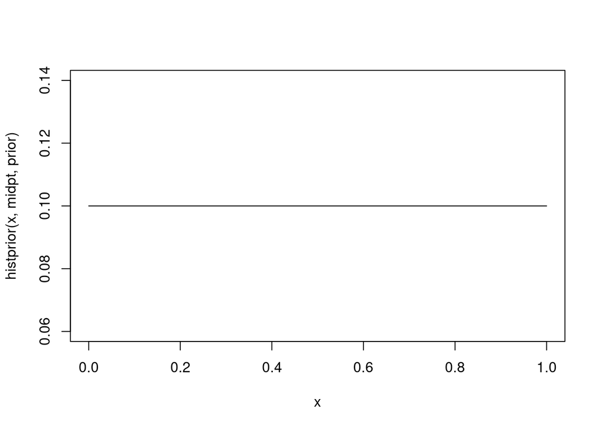

```r
midpt = seq(0.05, 0.95, by = 0.1)
prior = rep(0.1, 10) # 無情報事前分布
curve(histprior(x, midpt, prior), from = 0, to = 1)
```

### 事後分布

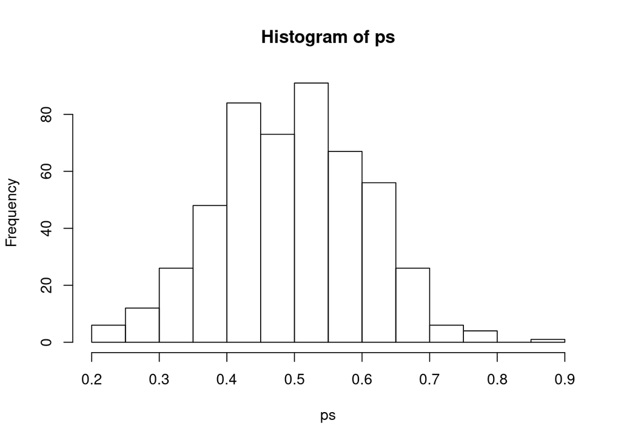

```r
p = seq(0, 1, length = 500)
posterior = c()
for (i in length(p)) {
  min_idx = which.min(abs(midpt - p[i]))
  posterior = c(posterior, dbeta(p, 10, 10) * prior[min_idx]) # コイン Head 10, Tail = 10
}
posterior = posterior / sum(posterior)
ps = sample(p, replace = TRUE, prob = posterior)
hist(ps)
```

## 2-3

### 事前分布

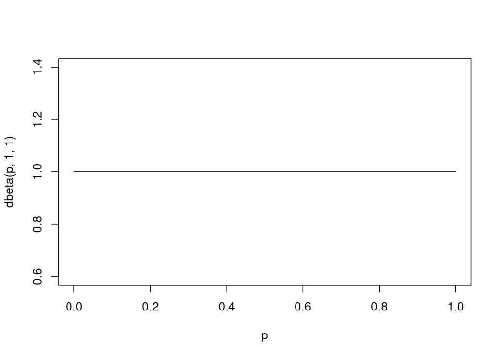

```r
p = seq(0, 1, length=100)
plot(p, dbeta(p, 1, 1), type ="l")
```

### 事後分布

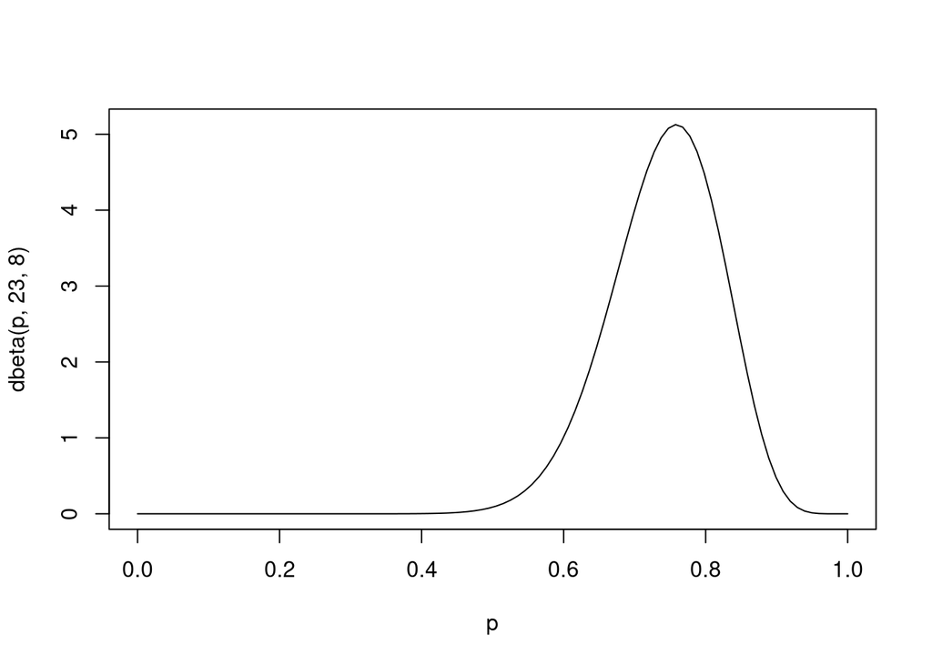

```r
p = seq(0, 1, length=100)
plot(p, dbeta(p, 23, 8), type ="l")
```

### (a)

```r
qbeta(c(0.5, 0.95), 23, 8)
```

```
## [1] 0.7471911 0.8598149
```

### (b)

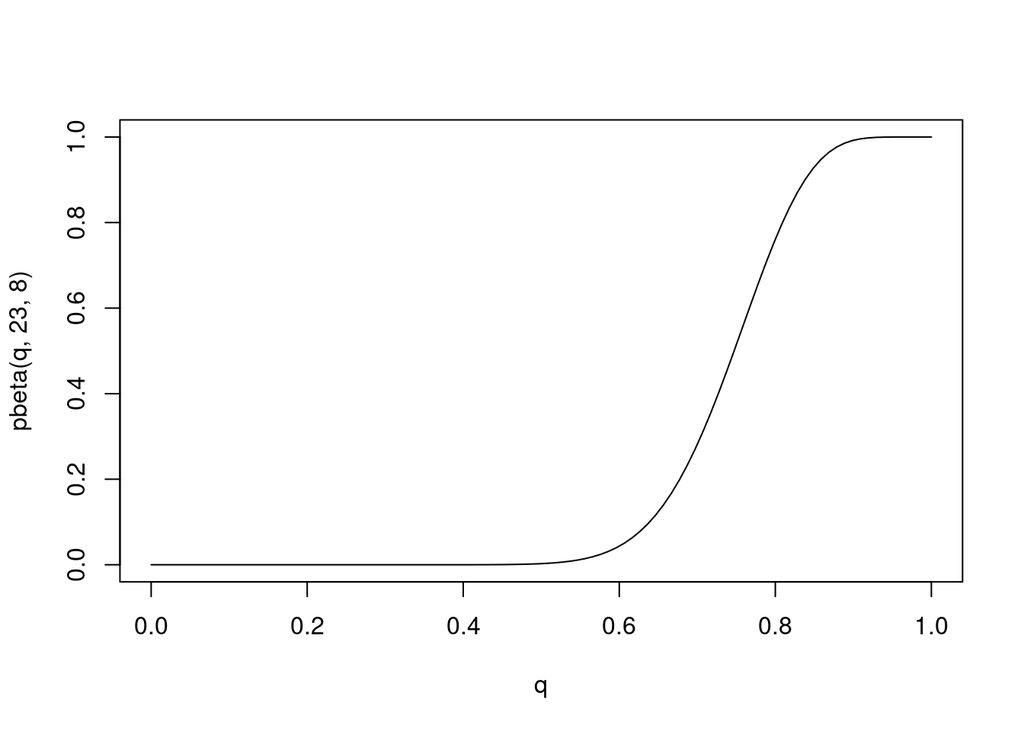

```r
q = seq(0, 1, length=100)
plot(q, pbeta(q, 23, 8), type ="l")
```

```r
1 - pbeta(0.6, 23, 8)
```

```
## [1] 0.9564759
```

### (c)

```r
rbeta(1000, 23, 8)
```

[output not shown]

[output cut: 128 more lines]

### (d)

さらに、10人いる場合の高校を卒業する人数 $X$ の予測分布を求める．

$$p(x) = \int_{0}^{1} \binom{10}{x}p^{x}(1-p)^{10-x} Beta(p|23,8) dp$$

$$\begin{aligned}
p(X=9)
&= \int_{0}^{1} \binom{10}{9}p^{9}(1-p)^{10-9} Beta(p|23,8) dp \\
&= \int_{0}^{1} 10 \cdot p^{9}(1-p) Beta(p|23,8) dp \\
&= \frac{10}{B(23, 8)} \int_{0}^{1} p^{9}(1-p) p^{22} (1-p)^{7} dp \\
&= \frac{10}{B(23, 8)} \int_{0}^{1} p^{31}(1-p)^{8} dp \\
&= \frac{10}{B(23, 8)} \int_{0}^{1} p^{32 - 1}(1-p)^{9 - 1} dp \\
&= \frac{10}{B(23, 8)} B(32, 9) \\
\end{aligned}$$

```r
10 * beta(32, 9) / beta(23, 8)
```

```
## [1] 0.1902656
```

$$\begin{aligned}
p(X=10)
&= \int_{0}^{1} \binom{10}{10}p^{10}(1-p)^{10-10} Beta(p|23,8) dp \\
&= \int_{0}^{1} p^{10} Beta(p|23,8) dp \\
&= \frac{1}{B(23, 8)} \int_{0}^{1} p^{10} p^{22} (1-p)^{7} dp \\
&= \frac{1}{B(23, 8)} \int_{0}^{1} p^{32}(1-p)^{7} dp \\
&= \frac{1}{B(23, 8)} \int_{0}^{1} p^{33 - 1}(1-p)^{8 - 1} dp \\
&= \frac{1}{B(23, 8)} B(33, 8) \\
\end{aligned}$$

```r
beta(33, 8) / beta(23, 8)
```

```
## [1] 0.07610622
```

サンプリングすると以下のようにできる．  
よって、このときの $X = 9 \; or \; X = 10$ となる確率を求めれば良い.

$$p \sim Beta(p|23, 8) \\
x \sim Bin(x|10, p)$$

```r
p = rbeta(10000, 23, 8)
x = rbinom(10000, 10, p)
table(x) / 10000
```

```
## x
##      1      2      3      4      5      6      7      8      9     10
## 0.0002 0.0024 0.0094 0.0322 0.0787 0.1480 0.2250 0.2493 0.1818 0.0730
```

理論値と近い値となっていることが確認できる．

## 2-4

### (a)

```r
p = seq(0.1, 0.5, by=0.1)
p
```

```
## [1] 0.1 0.2 0.3 0.4 0.5
```

```r
prior = c(0.50, 0.2, 0.2, 0.05, 0.05)
mean = sum(p * prior)
mean
```

```
## [1] 0.195
```

```r
sd = sqrt(sum((p - mean)^2 * prior))
sd
```

```
## [1] 0.1160819
```

$Beta(p|3, 12)$ の場合、サンプリング近似を行う.

```r
sample = rbeta(10000, shape1 = 3, shape2 = 12)
mean(sample)
```

```
## [1] 0.1993212
```

```r
sd(sample)
```

```
## [1] 0.1002495
```

### (b)

通学者数 $Y$ に関して、以下の予測分布が計算できる.

#### 離散事前分布

$$p(y) = \sum_p \binom{12}{y} p^{y} (1-p)^{12-y} g(p)$$

```r
predict = c()
for (y in 0:12) {
  p_y = 0
  for (i in 1:length(p)) {
    p_y = p_y + choose(12, y) * p[i]^y * (1 - p[i])^(12 - y) * prior[i]
  }
  predict = c(predict, p_y)
}
predict
```

```
##  [1] 0.1578479672 0.2447719936 0.2093137913 0.1475812240 0.1001416403
##  [6] 0.0652427436 0.0393037888 0.0212231429 0.0098095892 0.0036170714
## [11] 0.0009692955 0.0001645993 0.0000131530
```

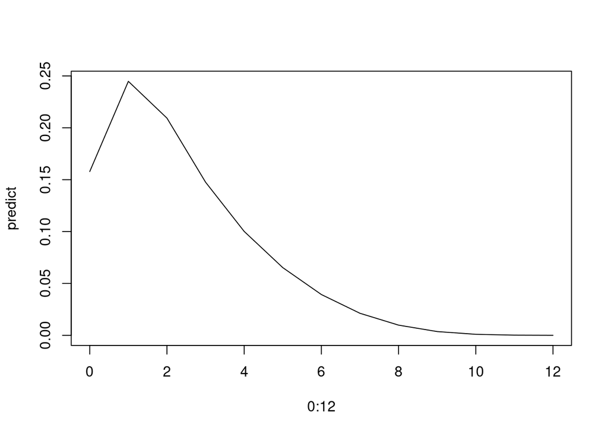

```r
plot(0:12, predict, type = "l")
```

```r
pdiscp(p, prior, 12, 0:12)
```

```
##  [1] 0.1578479672 0.2447719936 0.2093137913 0.1475812240 0.1001416403
##  [6] 0.0652427436 0.0393037888 0.0212231429 0.0098095892 0.0036170714
## [11] 0.0009692955 0.0001645993 0.0000131530
```

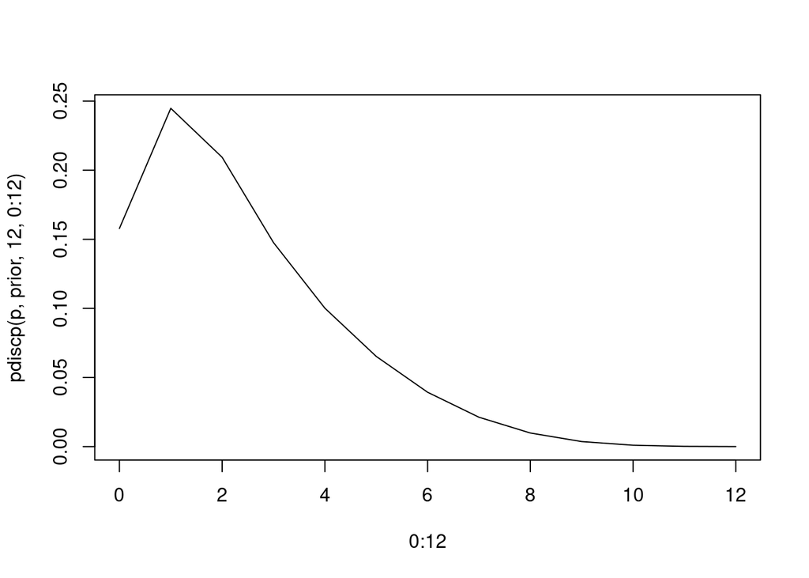

```r
plot(0:12, pdiscp(p, prior, 12, 0:12), type = "l")
```

#### ベータ分布

$$\begin{aligned}
p(y)
&= \int_0^1 \binom{12}{y} p^{y} (1-p)^{12-y} \frac{1}{B(3, 12)} p^{3 - 1} (1-p)^{12 - 1} dp \\
&= \binom{12}{y} \frac{1}{B(3, 12)} \int_0^1 p^{y + 2} (1-p)^{23-y} dp \\
&= \binom{12}{y} \frac{1}{B(3, 12)} B(y + 3, 24 - y) \\
\end{aligned}$$

```r
predict = c()
for (y in 0:12) {
  p_y = choose(12, y) * beta(y + 3, 24 - y) / beta(3, 12)
  predict = c(predict, p_y)
}
predict
```

```
##  [1] 1.400000e-01 2.191304e-01 2.191304e-01 1.739130e-01 1.173913e-01
##  [6] 6.919908e-02 3.588101e-02 1.628214e-02 6.360210e-03 2.072957e-03
## [11] 5.330462e-04 9.691749e-05 9.422533e-06
```

```r
sum(predict)
```

```
## [1] 1
```

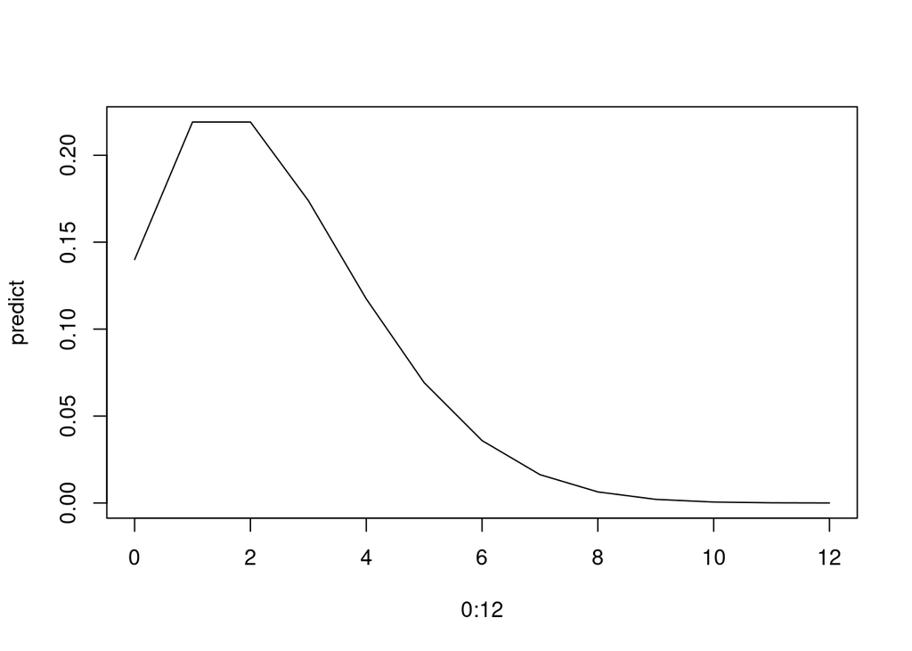

```r
plot(0:12, predict, type = "l")
```

```r
pbetap(c(3, 12), 12, 0:12)
```

```
##  [1] 1.400000e-01 2.191304e-01 2.191304e-01 1.739130e-01 1.173913e-01
##  [6] 6.919908e-02 3.588101e-02 1.628214e-02 6.360210e-03 2.072957e-03
## [11] 5.330462e-04 9.691749e-05 9.422533e-06
```

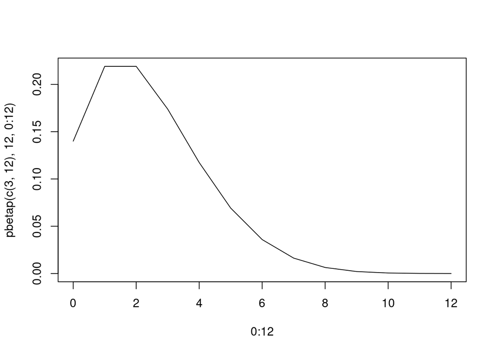

```r
plot(0:12, pbetap(c(3, 12), 12, 0:12), type = "l")
```

## 2-5

### (a)

```r
mu = seq(20, 70, by = 10)
prior = c(0.1, 0.15, 0.25, 0.25, 0.15, 0.1)
mu
```

```
## [1] 20 30 40 50 60 70
```

```r
prior
```

```
## [1] 0.10 0.15 0.25 0.25 0.15 0.10
```

### (b)

```r
y = c(38.6, 42.4, 57.5, 40.5, 51.7, 67.1, 33.4, 60.9, 64.1, 40.1, 40.7, 6.4)
ybar = mean(y)
ybar
```

```
## [1] 45.28333
```

### (c)

```r
likelihood = function (mu) exp(-1 * length(y) / (2 * 100) * (mu - ybar)^2)
like = likelihood(mu)
like
```

```
## [1] 2.201480e-17 8.192991e-07 1.873425e-01 2.632064e-01 2.272076e-06
## [6] 1.205079e-16
```

### (d)

```r
post = prior * like
post = post / sum(post)
post
```

```
## [1] 1.954479e-17 1.091063e-06 4.158078e-01 5.841881e-01 3.025731e-06
## [6] 1.069871e-16
```

### (e)

```r
dist = cbind(mu, post)
dist
```

```
##      mu         post
## [1,] 20 1.954479e-17
## [2,] 30 1.091063e-06
## [3,] 40 4.158078e-01
## [4,] 50 5.841881e-01
## [5,] 60 3.025731e-06
## [6,] 70 1.069871e-16
```

```r
discint(dist, 0.8)
```

```
## $prob
## [1] 0.9999959
##
## $set
## [1] 40 50
```

## 2-6

### (a)

```r
lambda = c(0.5, 1, 1.5, 2, 2.5, 3)
prior = c(0.1, 0.2, 0.3, 0.2, 0.15, 0.05)
likelihood = function (lambda) exp(-6 * lambda) * (6 * lambda)^12
post = prior * likelihood(lambda)
post = post / sum(post)
cbind(lambda, prior, round(post, 2))
```

```
##      lambda prior
## [1,]    0.5  0.10 0.00
## [2,]    1.0  0.20 0.04
## [3,]    1.5  0.30 0.36
## [4,]    2.0  0.20 0.37
## [5,]    2.5  0.15 0.20
## [6,]    3.0  0.05 0.03
```

### (b)

$$p(y|\lambda) = \exp{(-\lambda)}\frac{\lambda^y}{y!}$$

7 日間故障が起きない確率は、$p(y=0)^7$

$$p(y=0|\lambda)^7 = \exp{(-\lambda)}^7 = \exp{(-7\lambda)}$$

よって、予測確率は

$$p(y=0) = \sum_{\lambda} p(y=0|\lambda) p(\lambda)$$

```r
predict = 0
for (i in 1:length(lambda)) {
  predict = predict + exp(-7 * lambda[i]) * post[i]
}
predict
```

```
## [1] 4.640932e-05
```

## 3-1

```r
y = c(0, 10, 9, 8 ,11, 3, 3, 8, 8 ,11)
```

### (a)

```r
grid = seq(-2, 12, by = 0.1)
grid
```

```
##   [1] -2.0 -1.9 -1.8 -1.7 -1.6 -1.5 -1.4 -1.3 -1.2 -1.1 -1.0 -0.9 -0.8 -0.7 -0.6
##  [16] -0.5 -0.4 -0.3 -0.2 -0.1  0.0  0.1  0.2  0.3  0.4  0.5  0.6  0.7  0.8  0.9
##  [31]  1.0  1.1  1.2  1.3  1.4  1.5  1.6  1.7  1.8  1.9  2.0  2.1  2.2  2.3  2.4
##  [46]  2.5  2.6  2.7  2.8  2.9  3.0  3.1  3.2  3.3  3.4  3.5  3.6  3.7  3.8  3.9
##  [61]  4.0  4.1  4.2  4.3  4.4  4.5  4.6  4.7  4.8  4.9  5.0  5.1  5.2  5.3  5.4
##  [76]  5.5  5.6  5.7  5.8  5.9  6.0  6.1  6.2  6.3  6.4  6.5  6.6  6.7  6.8  6.9
##  [91]  7.0  7.1  7.2  7.3  7.4  7.5  7.6  7.7  7.8  7.9  8.0  8.1  8.2  8.3  8.4
## [106]  8.5  8.6  8.7  8.8  8.9  9.0  9.1  9.2  9.3  9.4  9.5  9.6  9.7  9.8  9.9
## [121] 10.0 10.1 10.2 10.3 10.4 10.5 10.6 10.7 10.8 10.9 11.0 11.1 11.2 11.3 11.4
## [136] 11.5 11.6 11.7 11.8 11.9 12.0
```

### (b)

```r
post = c()
for (i in 1:length(grid)) {
  post = c(post, prod(1 / (1 + (y - grid[i])^2)))
}
post = post / sum(post)
post
```

```
##   [1] 1.126701e-12 1.496731e-12 1.998369e-12 2.681960e-12 3.618341e-12
##   [6] 4.907571e-12 6.691425e-12 9.171224e-12 1.263306e-11 1.748306e-11
##  [11] 2.429564e-11 3.387761e-11 4.734937e-11 6.624058e-11 9.259000e-11
##  [16] 1.290277e-10 1.788063e-10 2.457439e-10 3.340655e-10 4.481838e-10
##  [21] 5.925432e-10 7.716980e-10 9.907641e-10 1.256265e-09 1.577282e-09
##  [26] 1.966808e-09 2.443283e-09 3.032471e-09 3.769918e-09 4.704408e-09
##  [31] 5.902894e-09 7.457609e-09 9.496316e-09 1.219707e-08 1.580947e-08
##  [36] 2.068510e-08 2.732094e-08 3.642051e-08 4.897829e-08 6.639260e-08
##  [41] 9.060846e-08 1.242817e-07 1.709331e-07 2.350204e-07 3.217946e-07
##  [46] 4.367471e-07 5.844460e-07 7.667233e-07 9.805828e-07 1.216761e-06
##  [51] 1.460147e-06 1.692662e-06 1.897806e-06 2.064831e-06 2.190700e-06
##  [56] 2.279372e-06 2.339409e-06 2.381300e-06 2.415471e-06 2.451242e-06
##  [61] 2.496573e-06 2.558281e-06 2.642503e-06 2.755231e-06 2.902879e-06
##  [66] 3.092862e-06 3.334235e-06 3.638441e-06 4.020242e-06 4.498945e-06
##  [71] 5.100067e-06 5.857626e-06 6.817372e-06 8.041376e-06 9.614637e-06
##  [76] 1.165467e-05 1.432560e-05 1.785902e-05 2.258530e-05 2.898085e-05
##  [81] 3.774050e-05 4.988895e-05 6.695444e-05 9.124112e-05 1.262594e-04
##  [86] 1.774089e-04 2.530649e-04 3.663029e-04 5.376134e-04 7.991090e-04
##  [91] 1.200852e-03 1.819899e-03 2.772146e-03 4.225372e-03 6.408220e-03
##  [96] 9.603697e-03 1.410919e-02 2.014539e-02 2.771668e-02 3.647081e-02
## [101] 4.565149e-02 5.422549e-02 6.116538e-02 6.574884e-02 6.771668e-02
## [106] 6.723693e-02 6.474535e-02 6.077250e-02 5.582661e-02 5.034240e-02
## [111] 4.467224e-02 3.909187e-02 3.380540e-02 2.894759e-02 2.458832e-02
## [116] 2.074307e-02 1.738861e-02 1.448031e-02 1.196713e-02 9.801610e-03
## [121] 7.944263e-03 6.363233e-03 5.031358e-03 3.923044e-03 3.012578e-03
## [126] 2.274241e-03 1.683455e-03 1.217945e-03 8.581987e-04 5.871043e-04
## [131] 3.891602e-04 2.498625e-04 1.556626e-04 9.443623e-05 5.606765e-05
## [136] 3.275997e-05 1.894430e-05 1.089840e-05 6.264988e-06 3.611696e-06
## [141] 2.093835e-06
```

### (c)

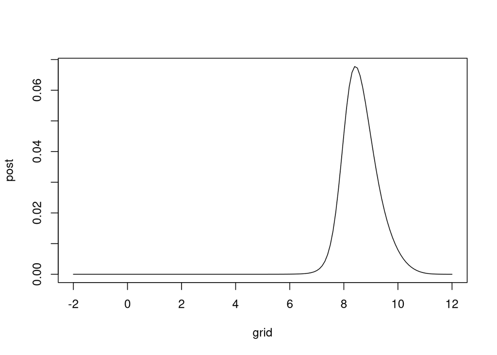

```r
plot(grid, post, type = "l")
```

### (d)

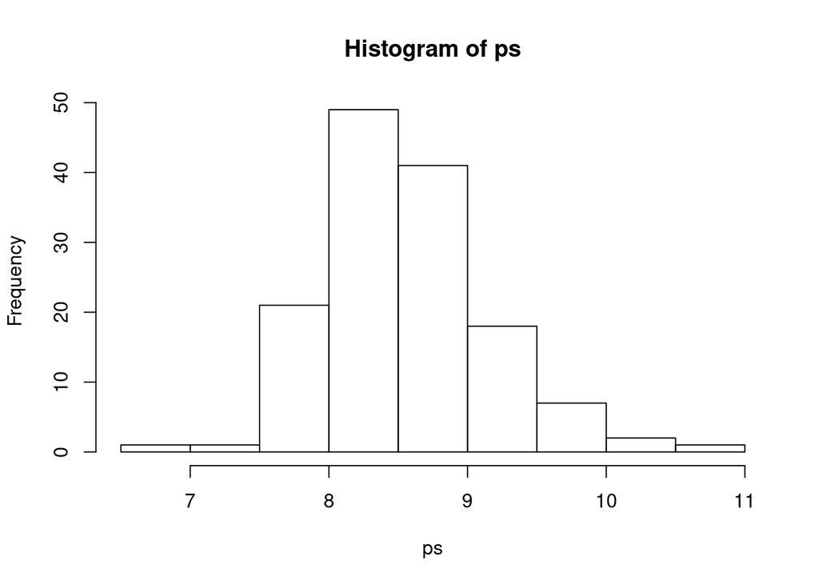

```r
ps = sample(grid, replace = TRUE, prob = post)
hist(ps)
```

```r
mean(ps)
```

```
## [1] 8.588652
```

```r
sd(ps)
```

```
## [1] 0.6105141
```

## 3-2

### (a)

$$g(\lambda|data) \propto \lambda^{-n-1} \exp{(-\frac{s}{\lambda})}$$

$$\theta = \frac{1}{\lambda} \\
\begin{aligned}
g(\theta|data)
&\propto \theta^{n+1} \exp{(-s \theta)} \cdot |\frac{d\lambda}{d\theta}| \\
&= \theta^{n+1} \exp{(-s \theta)} \cdot |\frac{d}{d\theta}\theta^{-1}| \\
&= \theta^{n+1} \exp{(-s \theta)} \cdot |-1 \cdot \theta^{-2}| \\
&= \theta^{n-1} \exp{(-s \theta)} \\
\end{aligned}$$

### (b)

1つの電球が切れるまでの時間を $X$ とすると、$X \sim Exp(x|\beta)$ と考えられる．

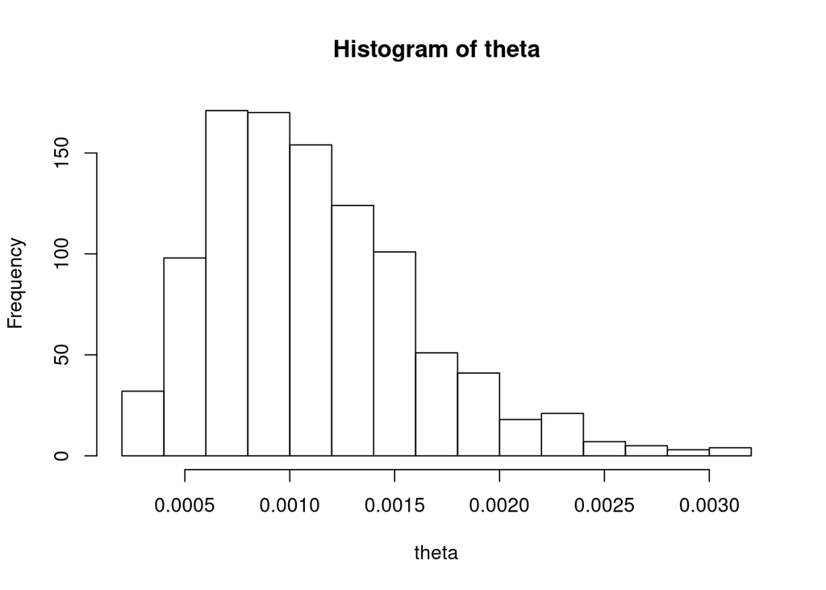

```r
x = c(751, 594, 1213, 1126, 819)
n = length(x)
s = sum(x)
theta = rgamma(1000, n, s)
hist(theta)
```

### (c)

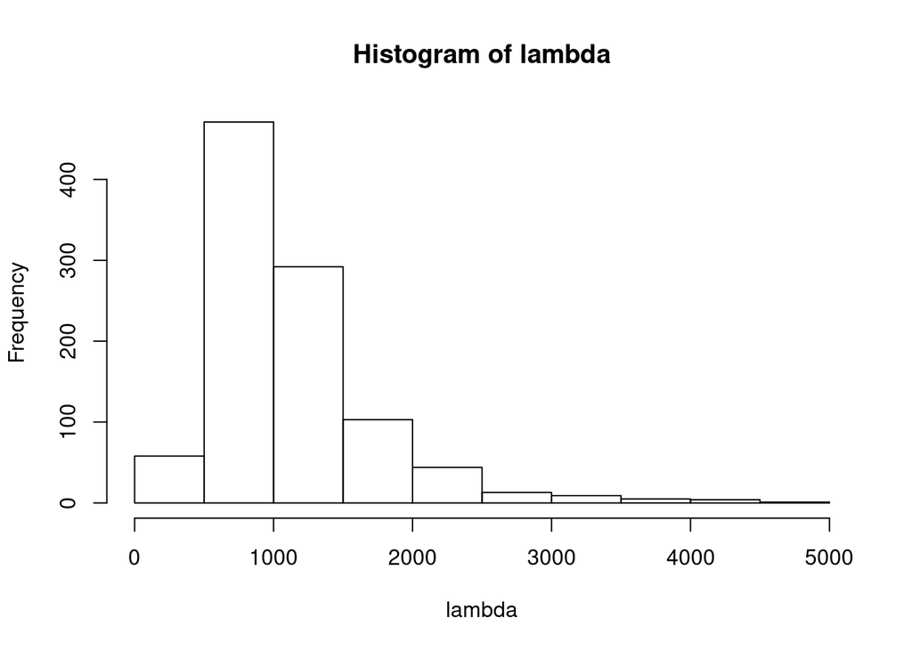

```r
lambda = 1 / theta
hist(lambda)
```

### (d)

```r
length(lambda[lambda > 1000]) / 1000
```

```
## [1] 0.471
```

## 3-3

$$\begin{aligned}
g(N|y)
&\propto \frac{1}{N^n}, \quad y_{(n)} \le N \le B \\
\end{aligned}$$

ここで、$N$ は最大値の分布であることから、$y_1, \ldots, y_n$ を観測した際には、初期の候補 $1 \le N \le B$ から上記へと分布が縮小する．(観測値の最大値以上の値になる)

### (a)

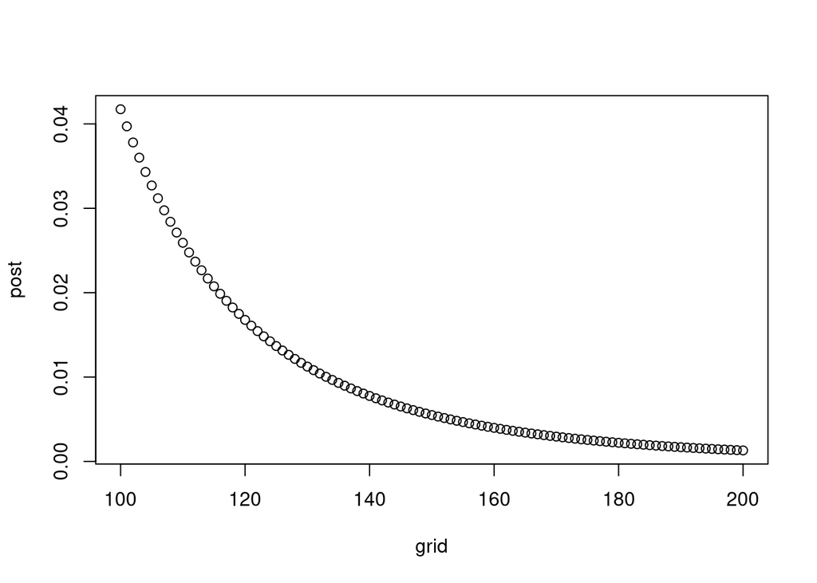

```r
n = 5
y = c(43, 24, 100, 35, 85)
B = 200
grid = seq(max(y), B, by = 1)
post = 1 / grid^n
post = post / sum(post)
plot(grid, post)
```

### (b)

```r
N = sample(grid, size = 1000, replace = TRUE, prob = post)
```

```r
mean(N)
```

```
## [1] 125.043
```

```r
sd(N)
```

```
## [1] 23.26539
```

### (c)

```r
length(N[N > 150]) / 1000
```

```
## [1] 0.158
```

## 3-4

### (a)

#### P1

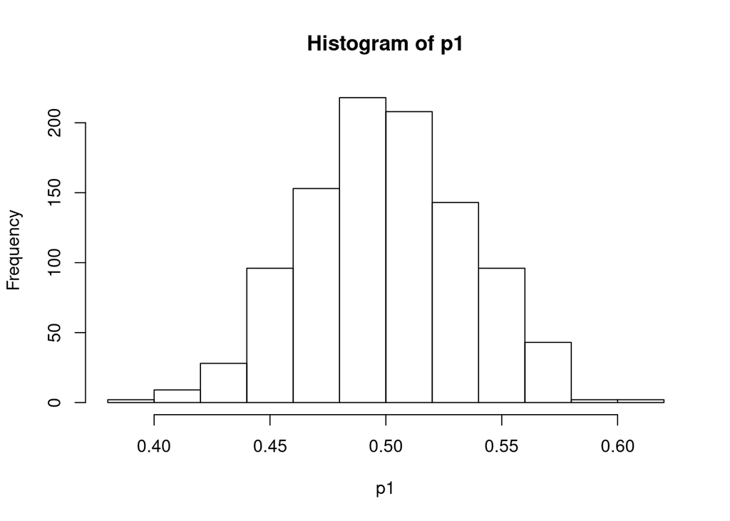

```r
m = 1000
p1 = rbeta(m, 100, 100)
hist(p1)
```

```r
length(p1[0.44 < p1 & p1 < 0.56]) / m
```

```
## [1] 0.914
```

#### P2

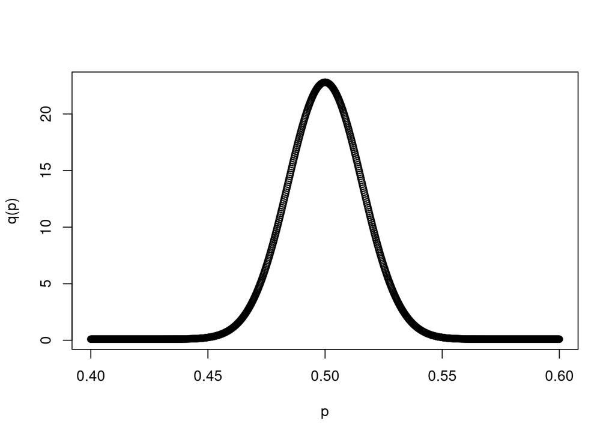

```r
q = function (p) 0.9 * dbeta(p, 500, 500) + 0.1 * dbeta(p, 1, 1)
p = seq(0.4, 0.6, length = 1000)
plot(p, q(p))
```

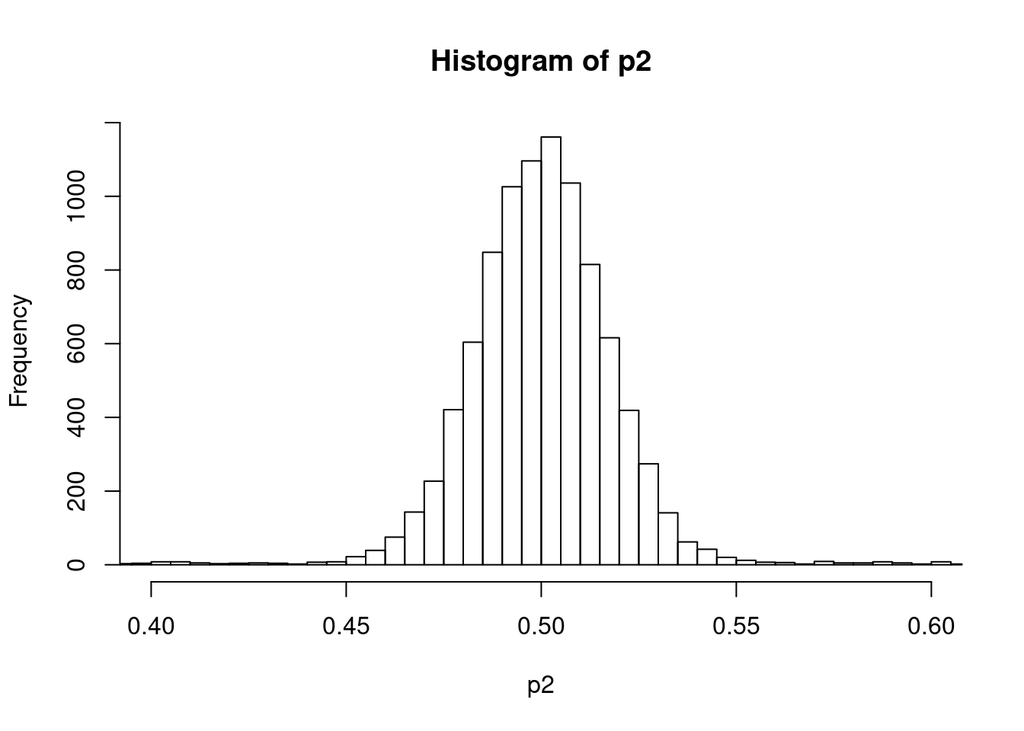

```r
m = 10000 # 1000 では分布の形を見るのには少ない
p2_sampling = function () {
  x = sample(c(0, 1), 1, prob = c(0.1, 0.9))
  if (x == 1) {
    return(rbeta(1, 500, 500))
  } else {
    return(rbeta(1, 1, 1))
  }
}
p2 = replicate(m, p2_sampling())
hist(p2, xlim = c(0.4, 0.6), breaks=seq(0, 1, 0.005))
```

```r
length(p2[0.44 < p2 & p2 < 0.56]) / m
```

```
## [1] 0.9121
```

### (b)

尤度は以下のようになる.

$$L(p) = \binom{100}{45} p^{45} (1-p)^{55}$$

#### P1

事後分布は、事前分布が $Beta(100, 100)$ で、表が 45 回出ているので、$Beta(145, 155)$ となる．

$$\begin{aligned}
p(p|data)
&\propto L(p) g(p) \\
&= \binom{100}{45} p^{45} (1-p)^{55} Beta(p|100, 100) \\
&\propto p^{45} (1-p)^{55} p^{100-1} (1-p)^{100-1} \\
&= p^{45 + 100 - 1} (1-p)^{55 + 100 - 1} \\
\end{aligned}$$

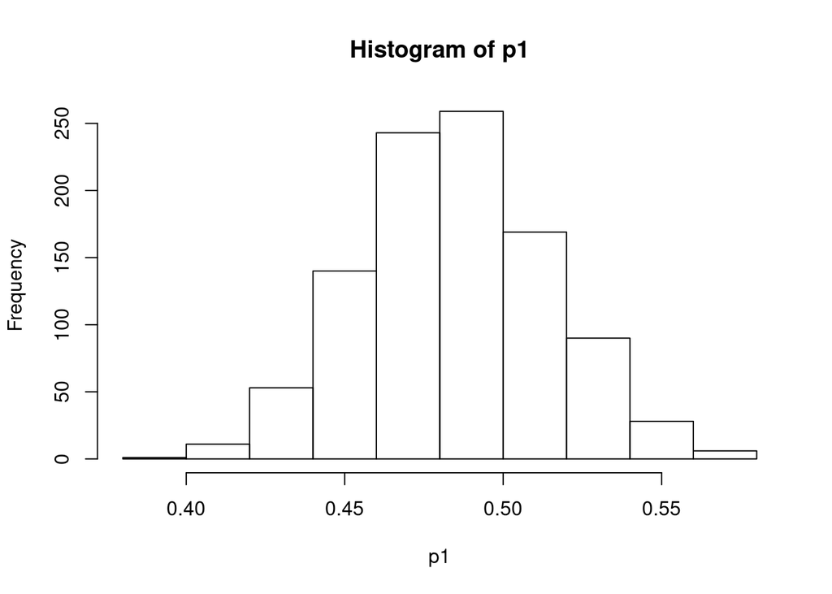

```r
p1 = rbeta(1000, 145, 155)
hist(p1)
```

```r
quantile(p1, c(0.05, 0.95))
```

```
##        5%       95%
## 0.4348357 0.5342714
```

#### P2

事後分布は、以下のようになる．

$$\begin{aligned}
p(p|data)
&\propto L(p) g(p) \\
&= \binom{100}{45} p^{45} (1-p)^{55} \{ 0.9 Beta(p|500, 500) + 0.1 Beta(p|1,1) \} \\
&= 0.9 \cdot \binom{100}{45} p^{45} (1-p)^{55} Beta(p|500, 500) + 0.1 \cdot \binom{100}{45} p^{45} (1-p)^{55} Beta(p|1,1) \\
&= 0.9 \cdot \binom{100}{45} p^{45} (1-p)^{55} \frac{1}{B(500, 500)} p^{500 - 1} (1-p)^{500 - 1} + 0.1 \cdot \binom{100}{45} p^{45} (1-p)^{55} \frac{1}{B(1, 1)} p^{1 - 1} (1-p)^{1 - 1} \\
&\propto 0.9 \cdot \frac{1}{B(500, 500)} p^{500 + 45 - 1} (1-p)^{500 + 55 - 1} + 0.1 \cdot \frac{1}{B(1, 1)} p^{1 + 45 - 1} (1-p)^{1 + 55 - 1} \\
&= 0.9 \cdot \frac{1}{B(500, 500)} p^{500 + 45 - 1} (1-p)^{500 + 55 - 1} + 0.1 \cdot p^{1 + 45 - 1} (1-p)^{1 + 55 - 1} \\
&= 0.9 \cdot \frac{B(545, 555)}{B(500, 500)} \frac{1}{B(545, 555)} p^{500 + 45 - 1} (1-p)^{500 + 55 - 1} + 0.1 \cdot B(46, 56) \frac{1}{B(46, 56)} p^{1 + 45 - 1} (1-p)^{1 + 55 - 1} \\
&= 0.9 \cdot \frac{B(545, 555)}{B(500, 500)} Beta(p|545, 555) + 0.1 \cdot B(46, 56) Beta(p|46, 56) \\
\end{aligned}$$

$\int Beta(p|545, 555) dp = 1, \int Beta(p|46, 56) dp = 1$ より、混合比率に関しては、混合比率を $\gamma$ とすると、以下の式になる．

$$\gamma : 1 - \gamma = 0.9 \cdot \frac{B(545, 555)}{B(500, 500)} : 0.1 \cdot B(46, 56) \\
\begin{aligned}
(1 - \gamma) \cdot (0.9 \cdot \frac{B(545, 555)}{B(500, 500)}) &= \gamma \cdot 0.1 \cdot B(46, 56) \\
(0.9 \cdot \frac{B(545, 555)}{B(500, 500)}) - \gamma \cdot (0.9 \cdot \frac{B(545, 555)}{B(500, 500)}) &= \gamma \cdot 0.1 \cdot B(46, 56) \\
\{ (0.9 \cdot \frac{B(545, 555)}{B(500, 500)}) + 0.1 \cdot B(46, 56) \} \gamma &= (0.9 \cdot \frac{B(545, 555)}{B(500, 500)})
\end{aligned}
\\
\gamma = \frac{(0.9 \cdot \frac{B(545, 555)}{B(500, 500)})}{(0.9 \cdot \frac{B(545, 555)}{B(500, 500)}) + 0.1 \cdot B(46, 56)}$$

よって、各項の係数は以下のようになる．

```r
tmp = exp(lbeta(545, 555) - lbeta(500, 500)) # overflow するので、log で計算
gamma = (0.9 * tmp) / (0.9 * tmp + 0.1 * beta(46, 56))
gamma
```

```
## [1] 0.9777615
```

```r
1 - gamma
```

```
## [1] 0.02223847
```

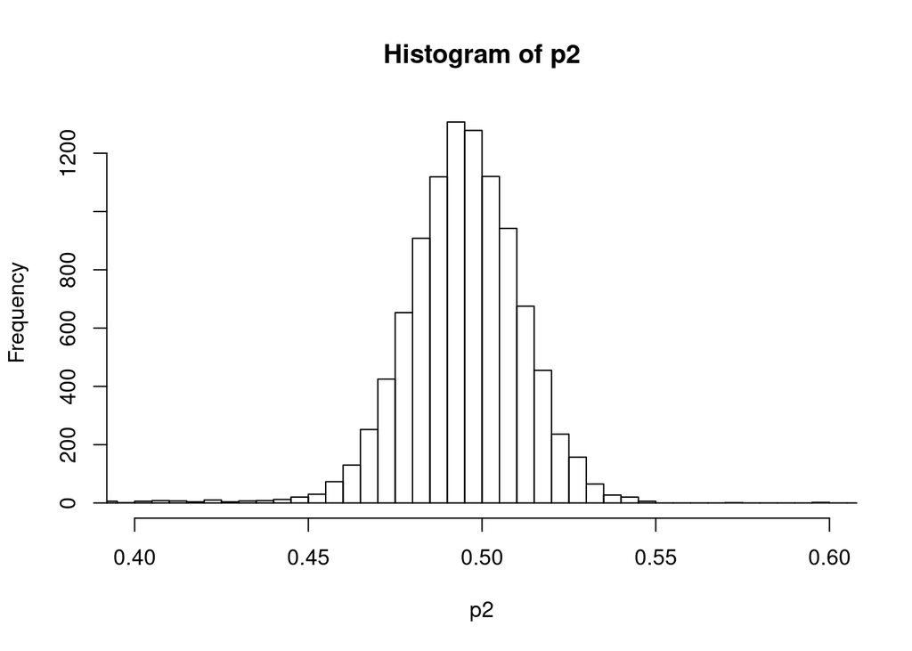

```r
m = 10000 # 1000 では分布の形を見るのには少ない
p2_sampling = function () {
  x = sample(c(0, 1), 1, prob = c(0.0222, 0.9778))
  if (x == 1) {
    return(rbeta(1, 545, 555))
  } else {
    return(rbeta(1, 46, 56))
  }
}
p2 = replicate(m, p2_sampling())
hist(p2, xlim = c(0.4, 0.6), breaks=seq(0, 1, 0.005))
```

```r
quantile(p2, c(0.05, 0.95))
```

```
##        5%       95%
## 0.4683059 0.5202097
```

LearnBayesを用いると以下になる．

```r
probs = c(0.9, 0.1)
beta.par1 = c(500, 500)
beta.par2 = c(1, 1)
betapar = rbind(beta.par1, beta.par2)
data = c(45, 55)
post = binomial.beta.mix(probs, betapar, data)
post
```

```
## $probs
##  beta.par1  beta.par2
## 0.97776153 0.02223847
##
## $betapar
##           [,1] [,2]
## beta.par1  545  555
## beta.par2   46   56
```

### (c)

#### P1

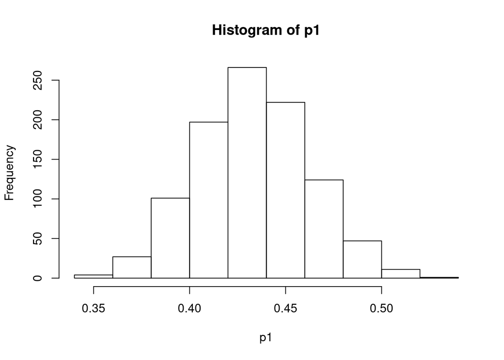

```r
p1 = rbeta(1000, 130, 170)
hist(p1)
```

```r
quantile(p1, c(0.05, 0.95))
```

```
##        5%       95%
## 0.3852962 0.4818855
```

#### P2

同様な計算から、

$$\begin{aligned}
p(p|data)
&\propto L(p) g(p) \\
&= 0.9 \cdot \frac{B(530, 570)}{B(500, 500)} f_B(p;530, 570) + 0.1 \cdot B(31, 71) f_B(p;31, 71) \\
\end{aligned}$$

混合比率に関しても同様に、

$$\gamma = \frac{(0.9 \cdot \frac{B(530, 570)}{B(500, 500)})}{(0.9 \cdot \frac{B(530, 570)}{B(500, 500)}) + 0.1 \cdot B(31, 71)}$$

よって、各項の係数は以下のようになる．

```r
tmp = exp(lbeta(530, 570) - lbeta(500, 500)) # overflow するので、log で計算
gamma = (0.9 * tmp) / (0.9 * tmp + 0.1 * beta(31, 71))
gamma
```

```
## [1] 0.0399307
```

```r
1 - gamma
```

```
## [1] 0.9600693
```

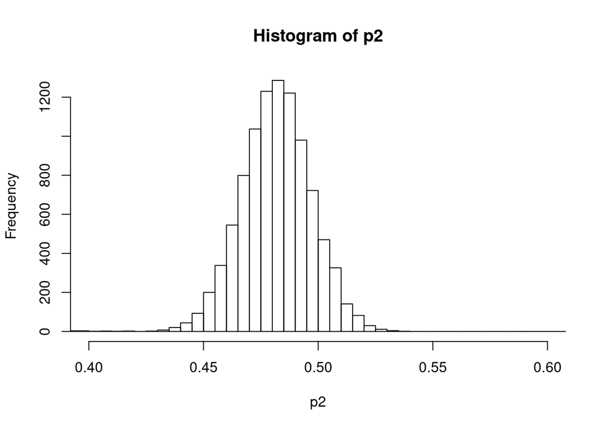

```r
m = 10000 # 1000 では分布の形を見るのには少ない
p2_sampling = function () {
  x = sample(c(0, 1), 1, prob = c(0.0399, 0.9601))
  if (x == 1) {
    return(rbeta(1, 530, 570))
  } else {
    return(rbeta(1, 31, 71))
  }
}
p2 = replicate(m, p2_sampling())
hist(p2, xlim = c(0.4, 0.6), breaks=seq(0, 1, 0.005))
```

```r
quantile(p2, c(0.05, 0.95))
```

```
##        5%       95%
## 0.4458550 0.5062934
```

LearnBayesを用いると以下になる．

```r
probs = c(0.9, 0.1)
beta.par1 = c(500, 500)
beta.par2 = c(1, 1)
betapar = rbind(beta.par1, beta.par2)
data = c(30, 70)
post = binomial.beta.mix(probs, betapar, data)
post
```

```
## $probs
## beta.par1 beta.par2
## 0.0399307 0.9600693
##
## $betapar
##           [,1] [,2]
## beta.par1  530  570
## beta.par2   31   71
```

### (d)

[output not shown]

## 3-5

### (a)

$$p(X = 8) = \binom{20}{8} p^{8} (1-p)^{20 - 8}$$

```r
dbinom(8, 20, 0.2)
```

```
## [1] 0.02216088
```

```r
choose(20, 8) * (0.2) ^ 8 * (1 - 0.2) ^ (20 - 8)
```

```
## [1] 0.02216088
```

### (b)

$$g(p) = 0.5I(p = 0.2) + 0.5I(p \ne 0.2) Beta(p|1,4)$$

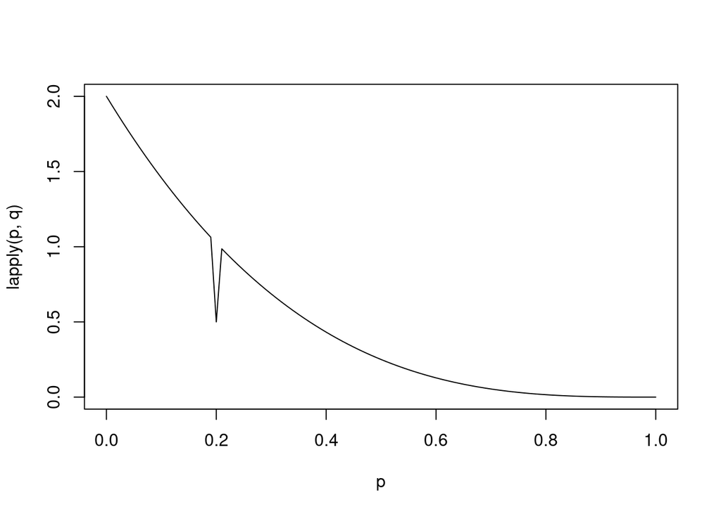

```r
q = function (p) {
  if (p == 0.2) {
    return(0.5)
  } else {
    return(0.5 * dbeta(p, 1, 4))
  }
}
p = seq(0, 1, by = 0.01)
plot(p, lapply(p, q), type = "l")
```

$$\begin{aligned}
p(p|data)
&\propto L(p) g(p) \\
&= \binom{20}{8} p^{8} (1-p)^{20 - 8} \{ 0.5I(p = 0.2) + 0.5I(p \ne 0.2) Beta(p|1,4) \} \\
&= \binom{20}{8} p^{8} (1-p)^{20 - 8} \frac{1}{2} I(p = 0.2) + \binom{20}{8} p^{8} (1-p)^{20 - 8} \frac{1}{2} I(p \ne 0.2) Beta(p|1,4) \\
&\propto p^{8} (1-p)^{20 - 8} I(p = 0.2) + p^{8} (1-p)^{20 - 8} I(p \ne 0.2) Beta(p|1,4) \\
&= p^{8} (1-p)^{20 - 8} I(p = 0.2) + p^{8} (1-p)^{20 - 8} I(p \ne 0.2) \frac{1}{B(1, 4)} p^{1 - 1} (1 - p)^{4 - 1} \\
&= p^{8} (1-p)^{20 - 8} I(p = 0.2) + I(p \ne 0.2) \frac{1}{B(1, 4)} p^{9 - 1} (1 - p)^{16 - 1} \\
&= p^{8} (1-p)^{20 - 8} I(p = 0.2) + I(p \ne 0.2) \frac{B(9 , 16)}{B(1, 4)} Beta(p|9 ,16) \\
\end{aligned}$$

$\int Beta(p|9 ,16) = 1$ と $p^{8} (1-p)^{20 - 8} I(p = 0.2) = (0.2)^8 (1 - 0.2)^{12}$ より、係数に関しては以下のようになる．

$$\gamma : 1 - \gamma = (0.2)^8 (1 - 0.2)^{12} : \frac{B(9 , 16)}{B(1, 4)} \\
\begin{aligned}
(1 - \gamma) \cdot (0.2)^8 (1 - 0.2)^{12} &= \gamma \cdot \frac{B(9 , 16)}{B(1, 4)} \\
(0.2)^8 (1 - 0.2)^{12} - \gamma \cdot (0.2)^8 (1 - 0.2)^{12} &= \gamma \cdot \frac{B(9 , 16)}{B(1, 4)} \\
\end{aligned}
\\
\gamma = \frac{(0.2)^8(1 - 0.2)^{12}}{(0.2)^8 (1 - 0.2)^{12} + \frac{B(9 , 16)}{B(1, 4)}}$$

```r
gamma = (0.2 ^ 8 * (1 - 0.2)^12) / (0.2 ^ 8 * (1 - 0.2)^12 + beta(9, 16)/beta(1, 4))
gamma
```

```
## [1] 0.3410395
```

```r
1 - gamma
```

```
## [1] 0.6589605
```

よって、今回の結果だと、$p = 0.2$ のときは、0.3410 となる． 一方で、(a) の結果は、0.02216088 である．

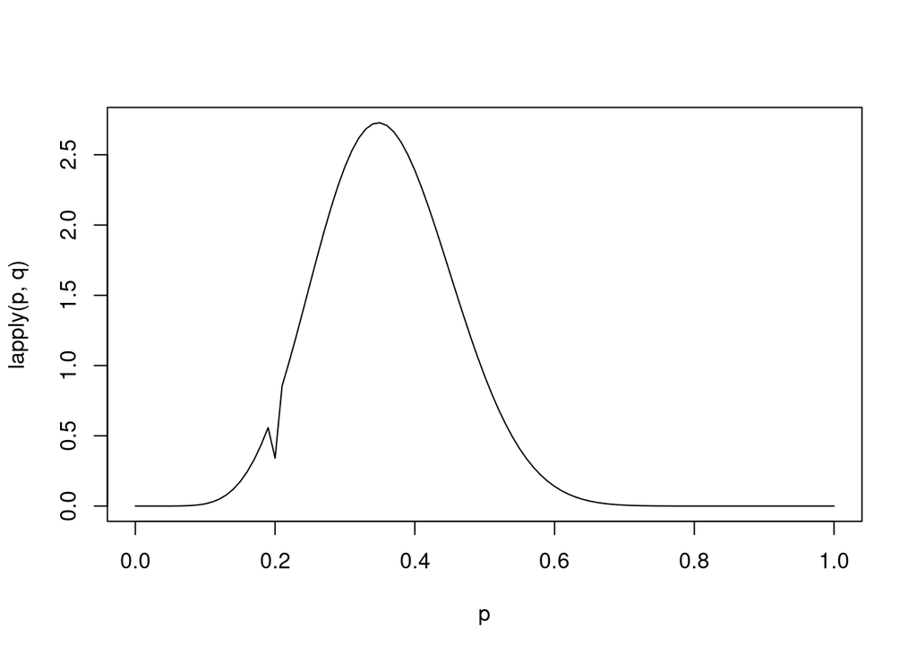

```r
q = function (p) {
  if (p == 0.2) {
    return(0.341)
  } else {
    return(0.659 * dbeta(p, 9, 16))
  }
}
p = seq(0, 1, by = 0.01)
plot(p, lapply(p, q), type = "l")
```

LearnBayes を用いると、以下になる．

```r
pbetat(0.2, .5, c(1, 4), c(8, 12))
```

```
## $bf
## [1] 0.5175417
##
## $post
## [1] 0.3410395
```

### (c)

#### (1)

$$g(p) = 0.5I(p = 0.2) + 0.5I(p \ne 0.2) Beta(p|0.5,2)$$

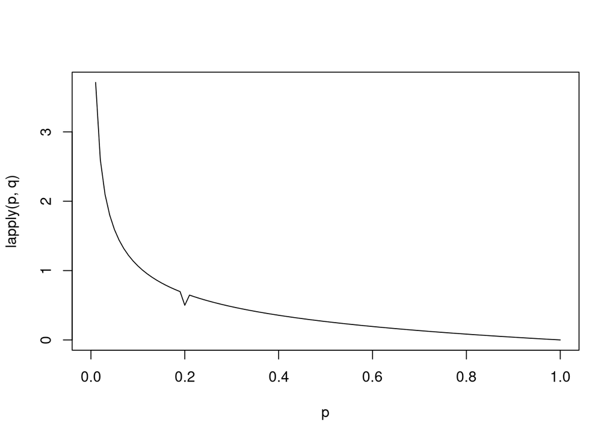

```r
q = function (p) {
  if (p == 0.2) {
    return(0.5)
  } else {
    return(0.5 * dbeta(p, 0.5, 2))
  }
}
p = seq(0, 1, by = 0.01)
plot(p, lapply(p, q), type = "l")
```

$$\begin{aligned}
p(p|data)
&\propto L(p) g(p) \\
&= p^{8} (1-p)^{20 - 8} I(p = 0.2) + I(p \ne 0.2) \frac{B(8.5, 14)}{B(0.5, 2)} Beta(p|8.5, 14) \\
\end{aligned}$$

$\int Beta(p|8.5, 14) = 1$ と $p^{8} (1-p)^{20 - 8} I(p = 0.2) = (0.2)^8 (1 - 0.2)^{12}$ より、係数に関しては以下のようになる．

$$\gamma : 1 - \gamma = (0.2)^8 (1 - 0.2)^{12} : \frac{B(8.5, 14)}{B(0.5, 2)} \\
\gamma = \frac{(0.2)^8(1 - 0.2)^{12}}{(0.2)^8 (1 - 0.2)^{12} + \frac{B(8.5, 14)}{B(0.5, 2)}}$$

```r
gamma = (0.2 ^ 8 * (1 - 0.2)^12) / (0.2 ^ 8 * (1 - 0.2)^12 + beta(8.5, 14)/beta(0.5, 2))
gamma
```

```
## [1] 0.3900752
```

```r
1 - gamma
```

```
## [1] 0.6099248
```

```r
pbetat(0.2, .5, c(0.5, 2), c(8, 12))
```

```
## $bf
## [1] 0.6395464
##
## $post
## [1] 0.3900752
```

#### (2)

$$g(p) = 0.5I(p = 0.2) + 0.5I(p \ne 0.2) Beta(p|2, 8)$$

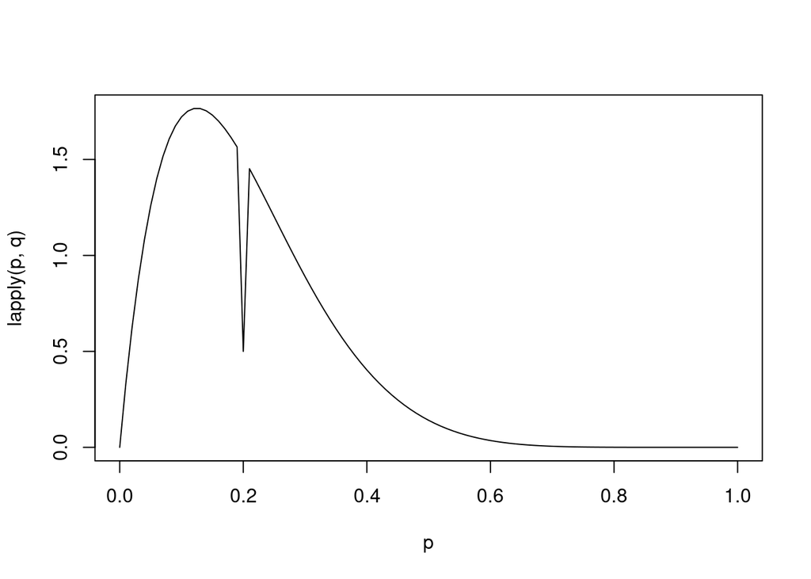

```r
q = function (p) {
  if (p == 0.2) {
    return(0.5)
  } else {
    return(0.5 * dbeta(p, 2, 8))
  }
}
p = seq(0, 1, by = 0.01)
plot(p, lapply(p, q), type = "l")
```

$$\begin{aligned}
p(p|data)
&\propto L(p) g(p) \\
&= p^{8} (1-p)^{20 - 8} I(p = 0.2) + I(p \ne 0.2) \frac{B(10, 20)}{B(2, 8)} Beta(p|10, 20) \\
\end{aligned}$$

$\int Beta(p|8.5, 14) = 1$ と $p^{8} (1-p)^{20 - 8} I(p = 0.2) = (0.2)^8 (1 - 0.2)^{12}$ より、係数に関しては以下のようになる．

$$\gamma : 1 - \gamma = (0.2)^8 (1 - 0.2)^{12} : \frac{B(10, 20)}{B(2, 8)} \\
\gamma = \frac{(0.2)^8(1 - 0.2)^{12}}{(0.2)^8 (1 - 0.2)^{12} + \frac{B(10, 20)}{B(2, 8)}}$$

```r
gamma = (0.2 ^ 8 * (1 - 0.2)^12) / (0.2 ^ 8 * (1 - 0.2)^12 + beta(10, 20)/beta(2, 8))
gamma
```

```
## [1] 0.328591
```

```r
1 - gamma
```

```
## [1] 0.671409
```

```r
pbetat(0.2, .5, c(2, 8), c(8, 12))
```

```
## $bf
## [1] 0.4894051
##
## $post
## [1] 0.328591
```

#### (3)

$$g(p) = 0.5I(p = 0.2) + 0.5I(p \ne 0.2) Beta(p|8, 32)$$

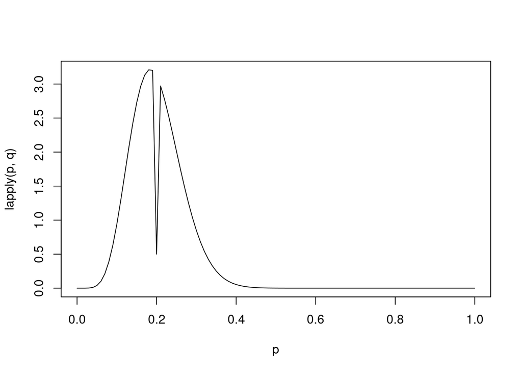

```r
q = function (p) {
  if (p == 0.2) {
    return(0.5)
  } else {
    return(0.5 * dbeta(p, 8, 32))
  }
}
p = seq(0, 1, by = 0.01)
plot(p, lapply(p, q), type = "l")
```

$$\begin{aligned}
p(p|data)
&\propto L(p) g(p) \\
&= p^{8} (1-p)^{20 - 8} I(p = 0.2) + I(p \ne 0.2) \frac{B(16, 44)}{B(8, 32)} Beta(p|16, 44) \\
\end{aligned}$$

$\int Beta(p|16, 44) = 1$ と $p^{8} (1-p)^{20 - 8} I(p = 0.2) = (0.2)^8 (1 - 0.2)^{12}$ より、係数に関しては以下のようになる．

$$\gamma : 1 - \gamma = (0.2)^8 (1 - 0.2)^{12} : \frac{B(16, 44)}{B(8, 32)} \\
\gamma = \frac{(0.2)^8(1 - 0.2)^{12}}{(0.2)^8 (1 - 0.2)^{12} + \frac{B(16, 44)}{B(8, 32)}}$$

```r
gamma = (0.2 ^ 8 * (1 - 0.2)^12) / (0.2 ^ 8 * (1 - 0.2)^12 + beta(16, 44)/beta(8, 32))
gamma
```

```
## [1] 0.3855337
```

```r
1 - gamma
```

```
## [1] 0.6144663
```

```r
pbetat(0.2, .5, c(8, 32), c(8, 12))
```

```
## $bf
## [1] 0.6274287
##
## $post
## [1] 0.3855337
```

### (d)

20回中8回当てる確率は 0.3 程度と考えられるので、ESP があるとは言えない．

## 3-6

速度平均 $\mu$、標準偏差 $\sigma = 10$ で正規分布であるので、70 マイルで追い越す確率は $P(\mu < 70) = \Phi(70, \mu, 10)$ である．よって、尤度は以下のように表せる.

$$L(\mu) \propto \Phi(70, \mu, 10)^s (1 - \Phi(70, \mu, 10))^f$$

### (a)

事前分布は一様分布($f(x) = C \quad (-\infty < x < \infty)$)であるとすると、

$$\begin{aligned}
p(\mu|data)
&\propto L(\mu) q(\mu) \\
&= C \cdot \Phi(70, \mu, 10) (1 - \Phi(70, \mu, 10))^{17} \\
&\propto \Phi(70, \mu, 10) (1 - \Phi(70, \mu, 10))^{17}
\end{aligned}$$

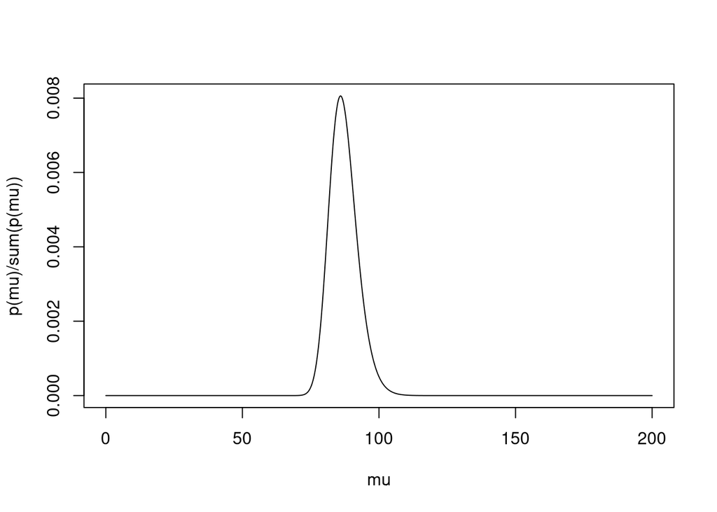

```r
# グリッド近似を用いる
mu = seq(0, 200, by = 0.1) # 速度は 0 以上であるので、加えて、最大値は 200 とした．
p = function (mu) {
  pnorm(70, mu, 10) * (1 - pnorm(70, mu, 10))^17
}
plot(mu, p(mu) / sum(p(mu)), type = "l")
```

### (b)

グリッド近似した際の、各グリッドの値を $\mu_i$、グリッド数を $N$ とすると、事後平均は以下のように表せる.

$$Mean = \sum_{i=1}^N \mu_i \cdot p(\mu_i)$$

```r
# グリッド近似を用いる
mu = seq(0, 200, by = 0.1) # 速度は 0 以上であるので、加えて、最大値は 200 とした．
p = function (mu) {
  pnorm(70, mu, 10) * (1 - pnorm(70, mu, 10))^17
}
post = p(mu) / sum(p(mu))
sum(mu * post) # 事後平均
```

```
## [1] 87.11109
```

### (c)

$P(\mu > 80)$ を求めればよいので、以下のようになる．

```r
mu = seq(0, 150, by = 0.1) # 速度は 0 以上であるので、加えて、最大値は 200 とした．
p = function (mu) {
  pnorm(70, mu, 10) * (1 - pnorm(70, mu, 10))^17
}
post = p(mu) / sum(p(mu))
sum(cbind(mu, post)[mu > 80, 2])
```

```
## [1] 0.9300158
```

$P(\mu > 80) = 1 - P(\mu \le 80) = 1 - \int_{-\infty}^{80} p(\mu) d\mu$ の数値積分は以下のようになる．

```r
p = function (mu) {
  pnorm(70, mu, 10) * (1 - pnorm(70, mu, 10))^17
}
z = integrate(p, 0, 150)$value # 正規化定数
int = integrate(p, -Inf, 80)
1 - int$value / z
```

```
## [1] 0.9316374
```

80 マイル近傍の事後分布は以下のようになる.

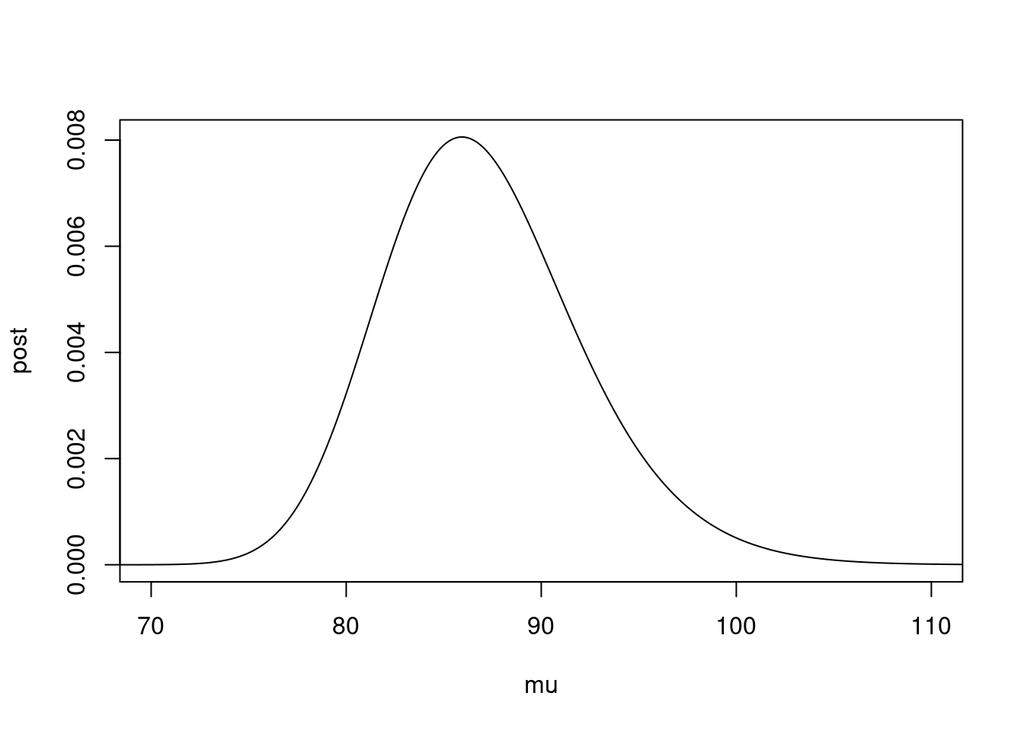

```r
mu = seq(0, 200, by = 0.1)
p = function (mu) {
  pnorm(70, mu, 10) * (1 - pnorm(70, mu, 10))^17
}
post = p(mu) / sum(p(mu))
plot(mu, post, xlim = c(70, 110), type = "l")
```

## 3-7

### (a)

$$g(\lambda) = 0.5 \cdot gamma(\lambda|1.5, 1000) + 0.5 \cdot gamma(\lambda|7, 1000)$$

ガンマ分布は以下で定義する．

$$gamma(\lambda|\alpha, \beta) = \frac{\beta^{\alpha}}{\Gamma(\alpha)} \lambda^{\alpha - 1} \exp{(-\beta\lambda)} \quad (\lambda > 0)$$

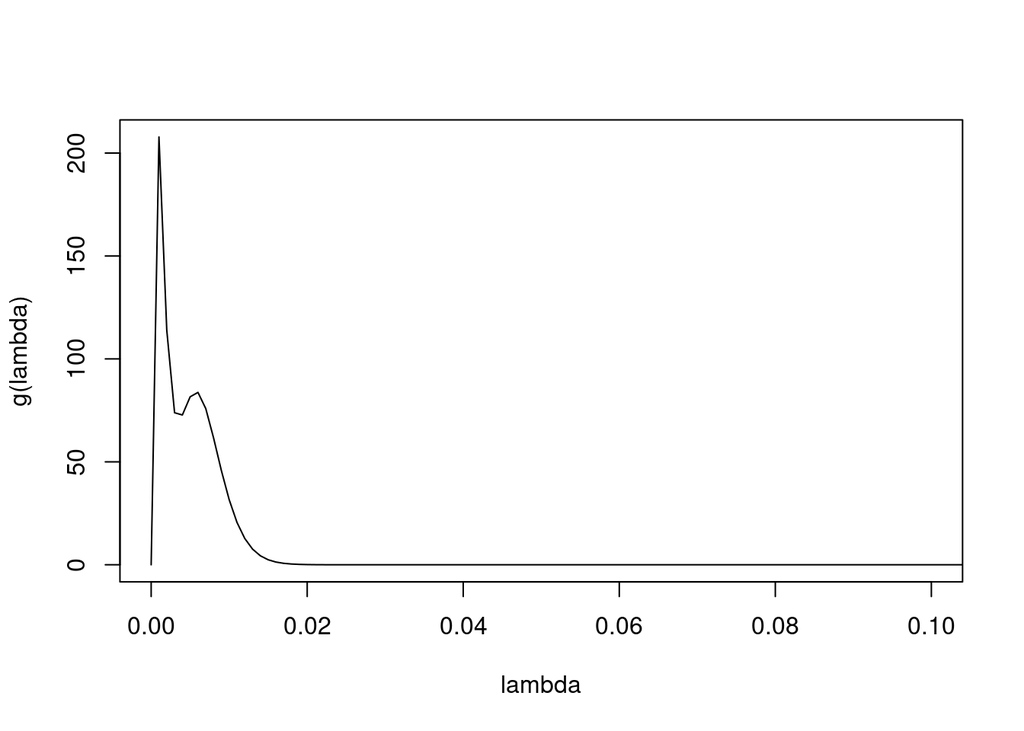

```r
lambda = seq(0, 1, by = 0.001)
g = function (lambda) {
  0.5 * dgamma(lambda, shape = 1.5, rate = 1000) + 0.5 * dgamma(lambda, shape = 7, rate = 1000)
}
plot(lambda, g(lambda), xlim = c(0, 0.1), type = "l")
```

### (b)

死亡数 $y$ は、暴露数 $e$ と死亡率 $\lambda$ としたとき、平均 $e\lambda$ のポアソン分布に従うと考えられる．

$$p(y) = Po(e\lambda) = \frac{(e\lambda)^{y}}{y!} \exp{(-e\lambda)}$$

よって、$y = 4, e = 1767$ の時の、尤度は以下の用に表せる．

$$L(\lambda) = \frac{(1767 \lambda)^{4}}{4!} \exp{(-1767\lambda)}$$

この時、$\lambda$ の事後分布は以下のようになる．

$$\begin{aligned}
p(\lambda|data)
&\propto L(\lambda) g(\lambda) \\
&= \frac{(1767 \lambda)^{4}}{4!} \exp{(-1767\lambda)} \{ 0.5 \cdot gamma(\lambda|1.5, 1000) + 0.5 \cdot gamma(\lambda|7, 1000) \} \\
&\propto \lambda^{4} \exp{(-1767\lambda)} \{gamma(\lambda|1.5, 1000) + gamma(\lambda|7, 1000) \} \\
&= \lambda^{4} \exp{(-1767\lambda)} \{ \frac{1000^{1.5}}{\Gamma(1.5)} \lambda^{1.5 - 1} \exp{(-1000\lambda)} + \frac{1000^{7}}{\Gamma(7)} \lambda^{7 - 1} \exp{(-1000\lambda)} \} \\
&= \frac{1000^{1.5}}{\Gamma(1.5)} \lambda^{1.5 + 4 - 1} \exp{(-2767\lambda)} + \frac{1000^{7}}{\Gamma(7)} \lambda^{7 + 4 - 1} \exp{(-2767\lambda)} \\
&= \frac{1000^{1.5}}{\Gamma(1.5)} \frac{\Gamma(5.5)}{2767^{5.5}} gamma(\lambda|5.5, 2767) + \frac{1000^{7}}{\Gamma(7)} \frac{\Gamma(11)}{2767^{11}} gamma(\lambda|11, 2767) \\
\end{aligned}$$

ここで、混合比率を $\pi$ とすると、

$$\pi : 1 - \pi = \frac{1000^{1.5}}{\Gamma(1.5)} \frac{\Gamma(5.5)}{2767^{5.5}} : \frac{1000^{7}}{\Gamma(7)} \frac{\Gamma(11)}{2767^{11}} \\
a = \frac{1000^{1.5}}{\Gamma(1.5)} \frac{\Gamma(5.5)}{2767^{5.5}}, b = \frac{1000^{7}}{\Gamma(7)} \frac{\Gamma(11)}{2767^{11}} \\
\pi = \frac{a}{a + b}$$

```r
a = (1000 ^ 1.5 * gamma(5.5)) / (gamma(1.5) * 2767 ^ 5.5)
b = (1000 ^ 7 * gamma(11)) / (gamma(7) * 2767 ^ 11)
pi = a / (a + b)
pi
```

```
## [1] 0.7597182
```

```r
1 - pi
```

```
## [1] 0.2402818
```

LearnBayes の場合は以下のようになる．

```r
probs = c(0.5, 0.5)
gamma.par1 = c(1.5, 1000)
gamma.par2 = c(7, 1000)
gammapar = rbind(gamma.par1, gamma.par2)
data = data.frame(t = 1767, y = 4)
post = poisson.gamma.mix(probs, gammapar, data)
post
```

```
## $probs
## gamma.par1 gamma.par2
##  0.7597182  0.2402818
##
## $gammapar
##            [,1] [,2]
## gamma.par1  5.5 2767
## gamma.par2 11.0 2767
```

### (c)

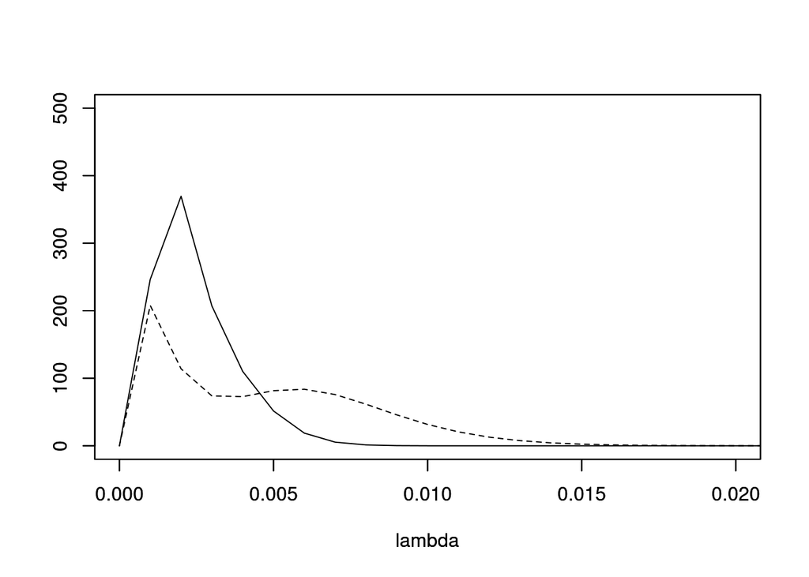

```r
lambda = seq(0, 1, by = 0.001)
g = function (lambda) {
  0.5 * dgamma(lambda, shape = 1.5, rate = 1000) + 0.5 * dgamma(lambda, shape = 7, rate = 1000)
}
post = function (lambda) {
  pi * dgamma(lambda, shape = 5.5, rate = 2767) + (1 - pi) * dgamma(lambda, shape = 11, rate = 2767)
}
plot(lambda, g(lambda), xlim = c(0, 0.02), ylim = c(0, 500), ylab = "", type = "l", lty = 2)
par(new=T)
plot(lambda, post(lambda), xlim = c(0, 0.02), ylim = c(0, 500), ylab = "", type = "l")
```

### (d)

$P(\lambda > 0.005) = 1 - P(\lambda \le 0.005) = 1 - \int_0^{0.005} p(\lambda) d\lambda$ である．

```r
# 数値積分
p = function (lambda) {
  return(pi * dgamma(lambda, shape = 5.5, rate = 2767) + (1 - pi) * dgamma(lambda, shape = 11, rate = 2767))
}
int = integrate(p, lower = 0, upper = 0.005)
1 - int$value
```

```
## [1] 0.04766545
```

```r
# サンプリング近似
post_sample = function () {
  x = sample(c(0, 1), 1, prob = c(1 - pi, pi))
  if (x == 1) {
    return(rgamma(1, shape = 5.5, rate = 2767))
  } else {
    return(rgamma(1, shape = 11, rate = 2767))
  }
}
sample = replicate(100000, post_sample())
sum(sample > 0.005) / 100000
```

```
## [1] 0.04825
```

```r
# グリッド近似
lambda = seq(0, 1, by = 0.000001)
p = function (lambda) {
  pi * dgamma(lambda, shape = 5.5, rate = 2767) + (1 - pi) * dgamma(lambda, shape = 11, rate = 2767)
}
post = p(lambda) / sum(p(lambda))
sum(cbind(lambda, post)[lambda > 0.005, 2])
```

```
## [1] 0.04763969
```

### (e)

混合確率は、$g_1(\lambda), g_2(\lambda)$ のそれぞれ 0.7597182、0.2402818 となっているので、このデータは $g_1(\lambda)$ に適合していると考えられる．

## 3-8

$$f(y:\lambda) = Exp(y|\lambda) \\
F(y;\lambda) = \int_{-\infty}^{y} f(y:\lambda) dy$$

であるとする．

### (a)

事前分布は以下とする．

$$p(\lambda) \propto \frac{1}{\lambda}$$

事後分布は以下になる．

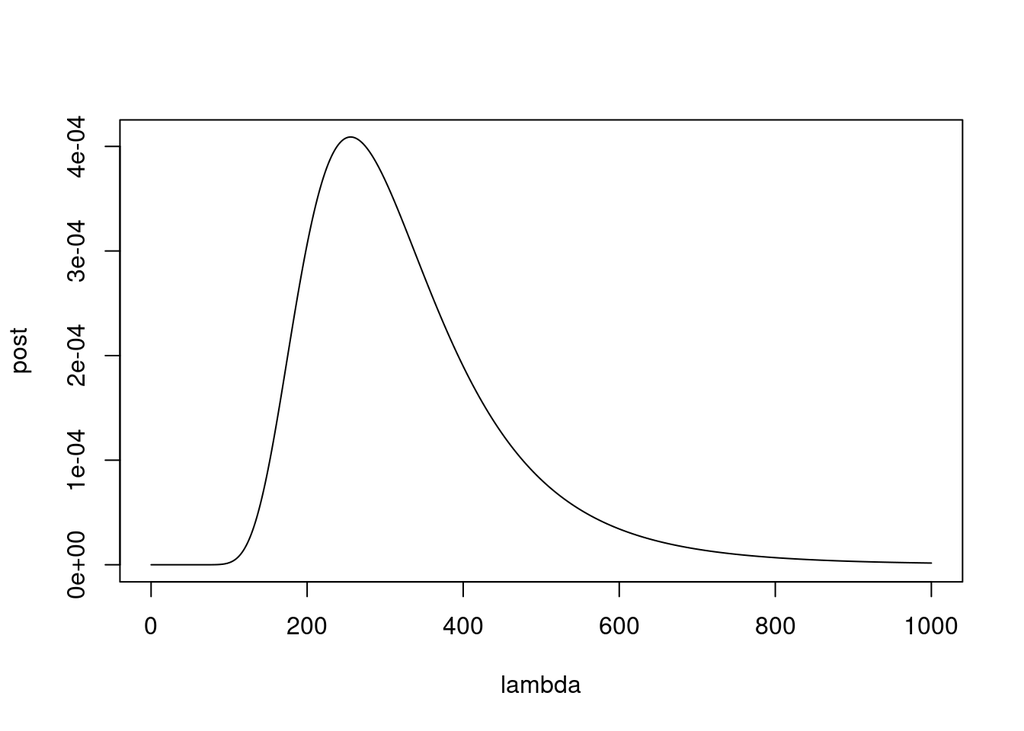

```r
# グリッド近似を用いる
lambda = seq(0.1, 1000, by = 0.1)
p = function (lambda) {
  likelihood = pexp(100, 1/lambda)^3 * dexp(100, 1/lambda) * (pexp(300, 1/lambda) - pexp(100, 1/lambda))^3 * dexp(300, 1/lambda) * (1 - pexp(300, 1/lambda))^4
  return(likelihood / lambda)
}
post = p(lambda)
post = post / sum(post)
plot(lambda, post, type = "l")
```

### (b)

```r
# グリッド近似を用いる
lambda = seq(0.1, 1000, by = 0.1)
p = function (lambda) {
  likelihood = pexp(100, 1/lambda)^3 * dexp(100, 1/lambda) * (pexp(300, 1/lambda) - pexp(100, 1/lambda))^3 * dexp(300, 1/lambda) * (1 - pexp(300, 1/lambda))^4
  return(likelihood / lambda)
}
post = p(lambda)
post = post / sum(post)
mu = sum(lambda * post)
mu
```

```
## [1] 327.2188
```

```r
sqrt(sum((lambda - mu)^2 * post))
```

```
## [1] 127.6595
```

### (c)

```r
# グリッド近似を用いる
lambda = seq(0.1, 1000, by = 0.1)
p = function (lambda) {
  likelihood = pexp(100, 1/lambda)^3 * dexp(100, 1/lambda) * (pexp(300, 1/lambda) - pexp(100, 1/lambda))^3 * dexp(300, 1/lambda) * (1 - pexp(300, 1/lambda))^4
  return(likelihood / lambda)
}
post = p(lambda)
post = post / sum(post)
sum(cbind(lambda, post)[300 < lambda & lambda < 500, 2])
```

```
## [1] 0.4059514
```